# Workbook to investigate Question 1

Paul Gittings

09/09/2020

```r
# function to load library, will first attempt to load package if not present
setupPackage <- function( packageName, loud=FALSE ) {
  if (!require(packageName, character.only=TRUE)) {
    install.packages(packageName, verbose = loud, dependencies = TRUE)
  }
  library(packageName, character.only=TRUE, verbose = loud)
}

setupPackage("tidyverse")
setupPackage("fastDummies")
setupPackage("PerformanceAnalytics")
setupPackage("corrr")
setupPackage("magrittr")
#setupPackage("polr")  #  ordinal logistic regression - not available for R 4.0.2 :-(, polr also in MASS package
setupPackage("ordinal")  # ordinal logistic regression
```

# Introduciton

The question to be investigated is: Does a relationship exist between the nature of the crash and the crash severity in motorcycle accidents?

Load the main crash data set and assign it to crashDF. EDA should reference crashDF

```r
  crashDF <- read_rds("../datasets/main.Rds")
```

# EDA

```r
col_names <- names(crashDF)
print(col_names)
```

```
##  [1] "X1"                              "crash_id"
##  [3] "Crash_Severity"                  "Crash_Year"
##  [5] "Crash_Month"                     "Crash_Day_Of_Week"
##  [7] "Crash_Hour"                      "Crash_Nature"
##  [9] "Crash_Type"                      "Crash_Longitude_GDA94"
## [11] "Crash_Latitude_GDA94"            "Crash_Street"
## [13] "Loc_Suburb"                      "Loc_Local_Government_Area"
## [15] "Loc_Post_Code"                   "Loc_Main_Roads_Region"
## [17] "Loc_ABS_Remoteness"              "Crash_Controlling_Authority"
## [19] "Crash_Roadway_Feature"           "Crash_Traffic_Control"
## [21] "Crash_Speed_Limit"               "Crash_Road_Surface_Condition"
## [23] "Crash_Atmospheric_Condition"     "Crash_Lighting_Condition"
## [25] "Crash_Road_Horiz_Align"          "Crash_Road_Vert_Align"
## [27] "Crash_DCA_Code"                  "Crash_DCA_Description"
## [29] "Crash_DCA_Group_Description"     "DCA_Key_Approach_Dir"
## [31] "Count_Casualty_Fatality"         "Count_Casualty_Hospitalised"
## [33] "Count_Casualty_MedicallyTreated" "Count_Casualty_MinorInjury"
## [35] "Count_Casualty_Total"            "Count_Unit_Motorcycle_Moped"
## [37] "site_id_1"                       "site_name_1"
## [39] "distance_1"                      "site_id_list_2"
## [41] "site_name_2"                     "distance_2"
## [43] "site_id_list_3"                  "site_name_3"
## [45] "distance_3"                      "Lat"
## [47] "Lon"                             "rainfall"
```

```r
unique(crashDF$Crash_Severity)
```

```
## [1] "Hospitalisation"      "Fatal"                "Medical treatment"
## [4] "Minor injury"         "Property damage only"
```

```r
unique(crashDF$Crash_Nature)
```

```
##  [1] "Angle"                         "Fall from vehicle"
##  [3] "Sideswipe"                     "Hit object"
##  [5] "Hit pedestrian"                "Rear-end"
##  [7] "Hit animal"                    "Head-on"
##  [9] "Non-collision - miscellaneous" "Hit parked vehicle"
## [11] "Struck by external load"       "Collision - miscellaneous"
## [13] "Overturned"
```

```r
#NOTE: Crash_Severity ~ Crash_Nature is predicting an ordinal factor based on a nominal one
```

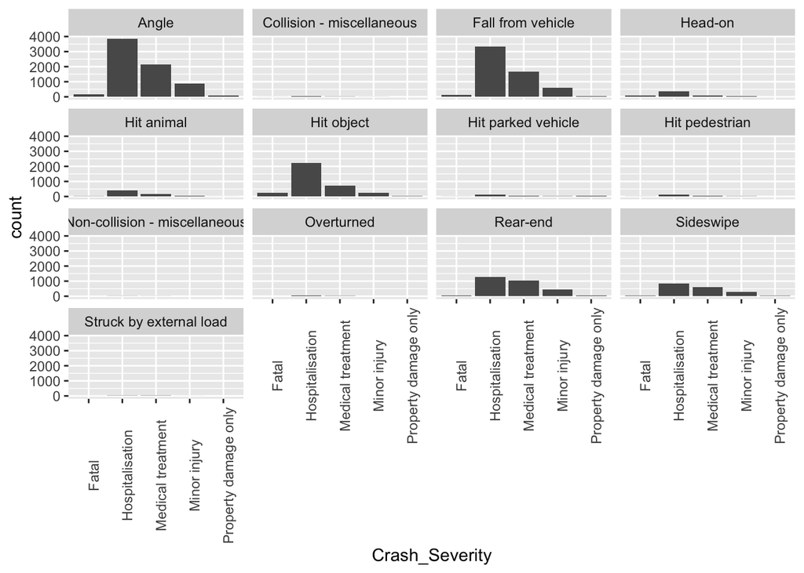

```r
ggplot(crashDF, aes(x=Crash_Severity)) +
  geom_bar(stat="count") +
  facet_wrap(~Crash_Nature) +
  theme(axis.text.x = element_text(angle = 90))
```

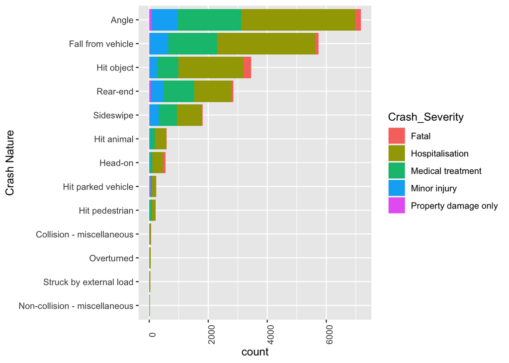

```r
ggplot(crashDF) +
    geom_bar(aes(x = forcats::fct_rev(forcats::fct_infreq(Crash_Nature)), fill = Crash_Severity)) +
    coord_flip() +
    theme(axis.text.x = element_text(angle = 90)) +
    xlab("Crash Nature")
```

Looking at the above plot, would it make sense to roll oup some of the Crash_Nature levels, say from “Hit Parked Vehicle” and all those to it’s left?

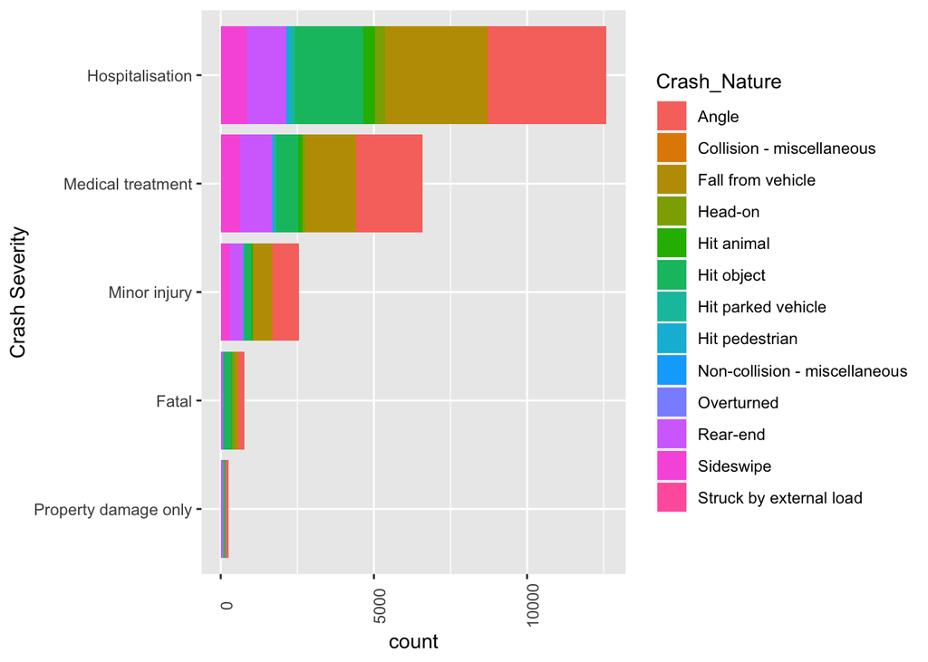

```r
ggplot(crashDF) +
    geom_bar(aes(x = forcats::fct_rev(forcats::fct_infreq(Crash_Severity)), fill = Crash_Nature)) +
    coord_flip() +
    theme(axis.text.x = element_text(angle = 90)) +
    xlab("Crash Severity")
```

```r
 crashDF %>%
  filter(Crash_Roadway_Feature == "No Roadway Feature") %>%
    ggplot() +
    geom_bar(aes(x = forcats::fct_rev(forcats::fct_infreq(Crash_Nature)), fill = Crash_Severity)) +
    coord_flip() +
    theme(axis.text.x = element_text(angle = 90)) +
    xlab("Crash Nature") +
    ggtitle("Nature of Crashes with no road feature")
```

[output not shown]

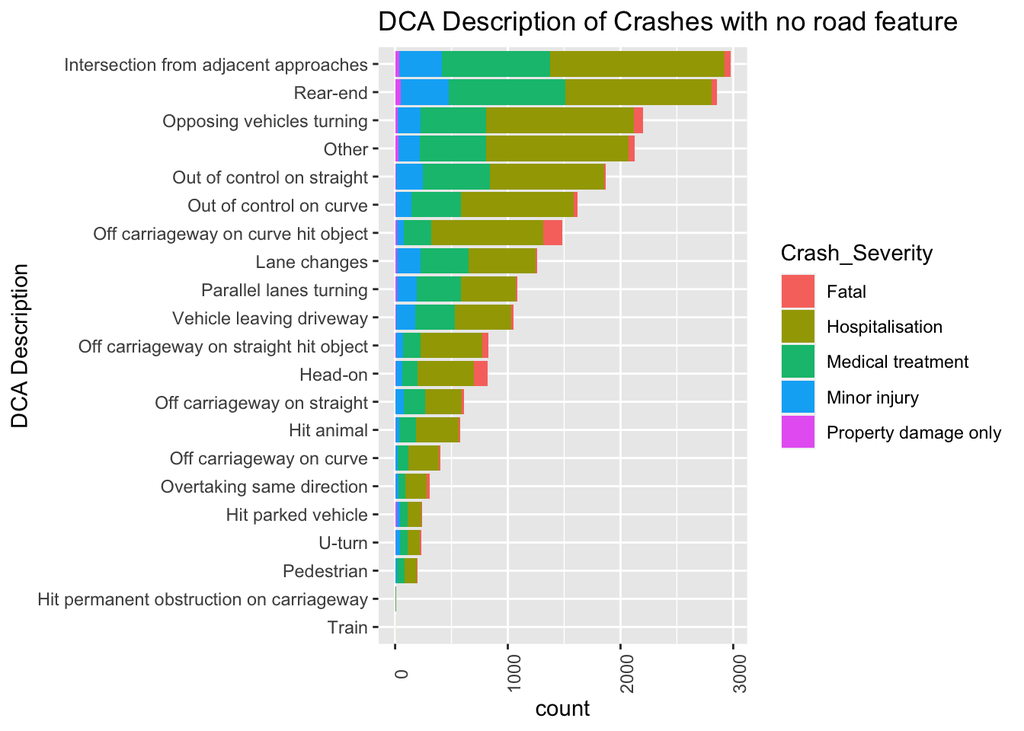

```r
 crashDF %>%
    ggplot() +
    geom_bar(aes(x = forcats::fct_rev(forcats::fct_infreq(Crash_DCA_Group_Description)), fill = Crash_Severity)) +
    coord_flip() +
    theme(axis.text.x = element_text(angle = 90)) +
    xlab("DCA Description") +
    ggtitle("DCA Description of Crashes with no road feature")
```

```r
 crashDF %>%
  filter(Crash_Roadway_Feature == "No Roadway Feature") %>%
    ggplot() +
    geom_bar(aes(x = forcats::fct_rev(forcats::fct_infreq(Crash_DCA_Group_Description)), fill = Crash_Severity)) +
    coord_flip() +
    theme(axis.text.x = element_text(angle = 90)) +
    xlab("DCA Description") +
    ggtitle("DCA Description of Crashes with no road feature")
```

[output not shown]

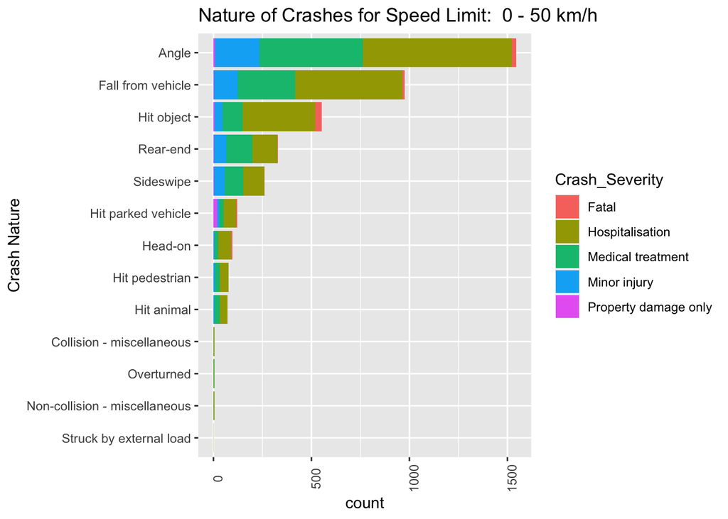

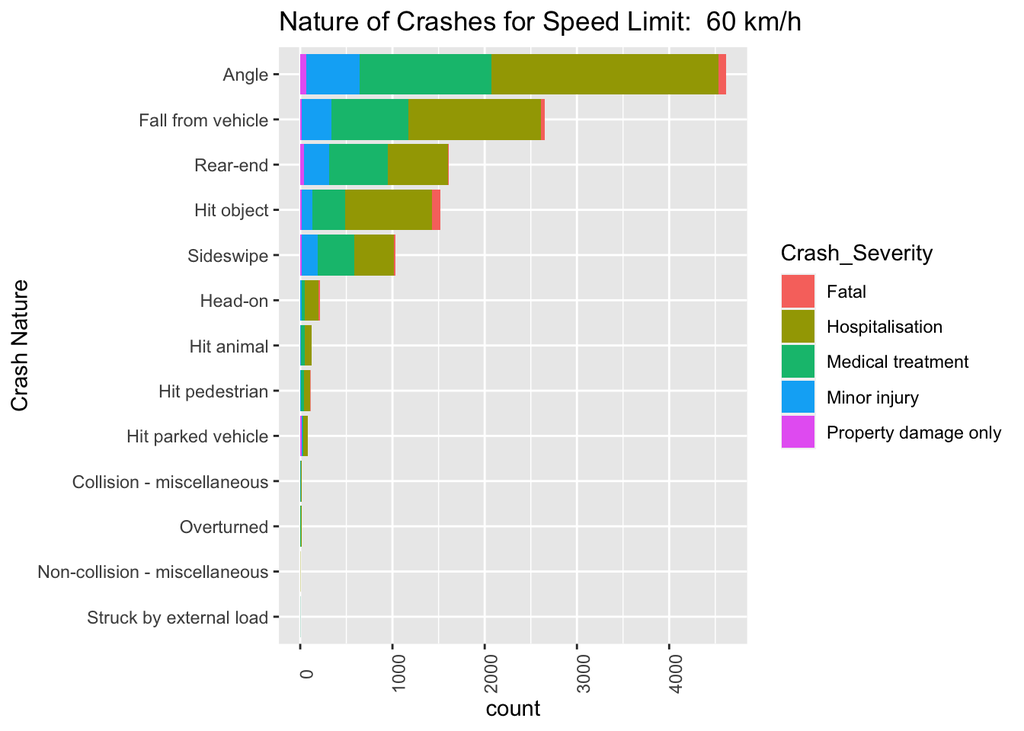

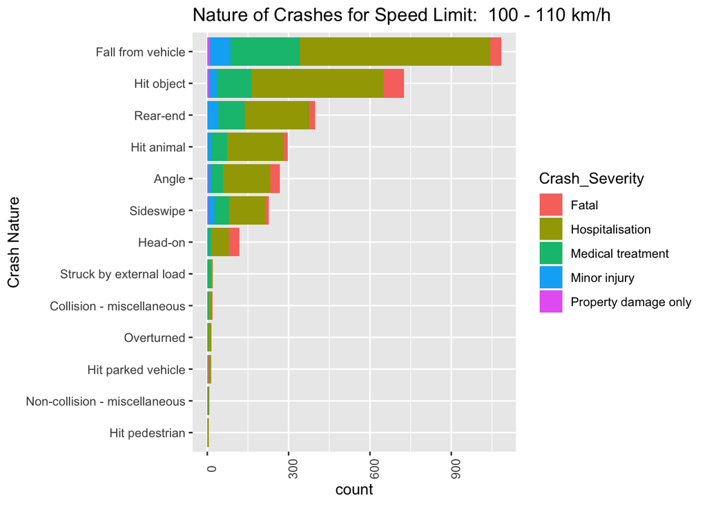

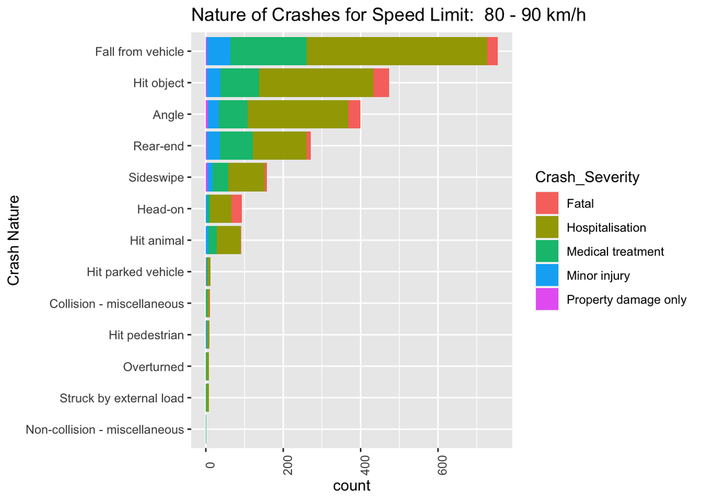

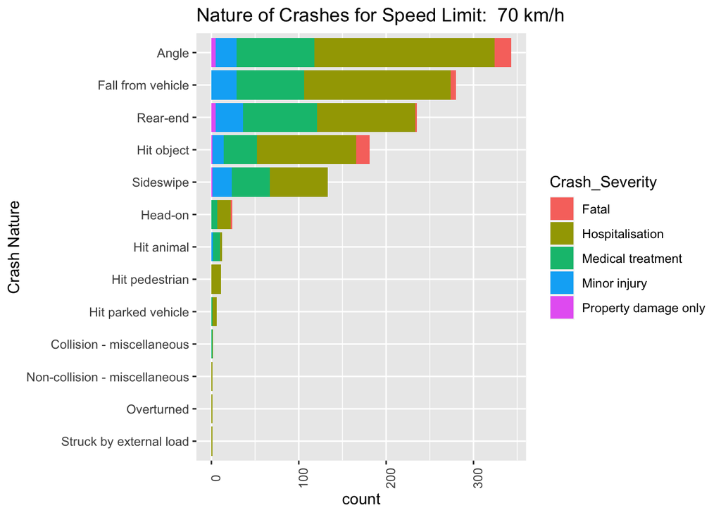

```r
speeds <- unique(crashDF$Crash_Speed_Limit)

for( speed in speeds){
  tmpData <- crashDF %>% filter(Crash_Speed_Limit == speed)
 print(
   ggplot(tmpData) +
    geom_bar(aes(x = forcats::fct_rev(forcats::fct_infreq(Crash_Nature)), fill = Crash_Severity)) +
    coord_flip() +
    theme(axis.text.x = element_text(angle = 90)) +
    xlab("Crash Nature") +
    ggtitle(paste ("Nature of Crashes for Speed Limit: ", speed))
  )
}
```

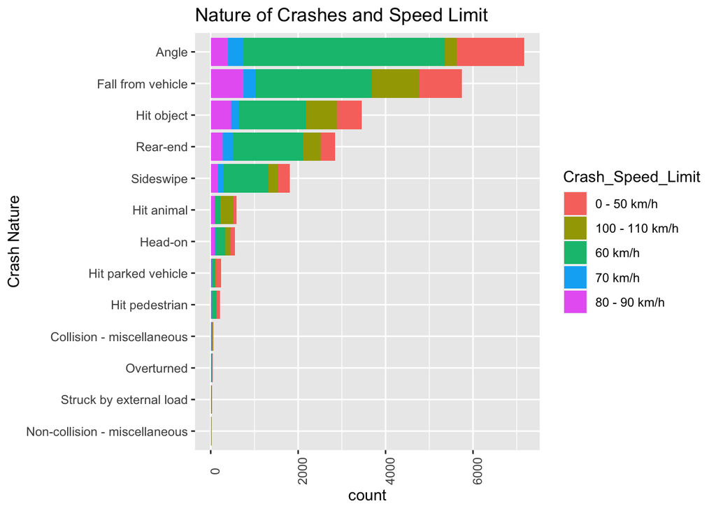

```r
   ggplot(crashDF) +
    geom_bar(aes(x = forcats::fct_rev(forcats::fct_infreq(Crash_Nature)), fill = Crash_Speed_Limit)) +
    theme(axis.text.x = element_text(angle = 90)) +
    xlab("Crash Nature") +
    coord_flip()+
    ggtitle("Nature of Crashes and Speed Limit")
```

```r
yearly_counts <- crashDF %>%
                 group_by(Crash_Year, Crash_Nature) %>%
                 summarise(count=n())
```

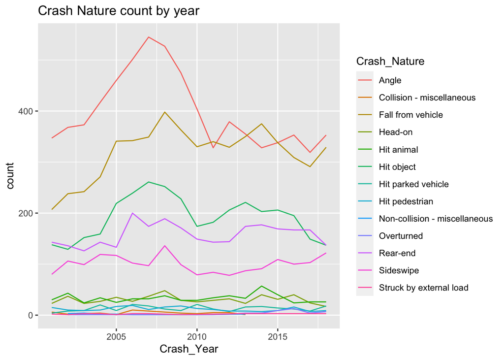

```r
ggplot(yearly_counts, aes(x=Crash_Year, y=count, group=Crash_Nature, color=Crash_Nature)) +
  geom_line() +
  ggtitle("Crash Nature count by year")
```

```r
feat_counts <- crashDF %>%
                 group_by(Crash_Atmospheric_Condition) %>%
                 summarise(count=sum(Count_Casualty_Fatality))
```

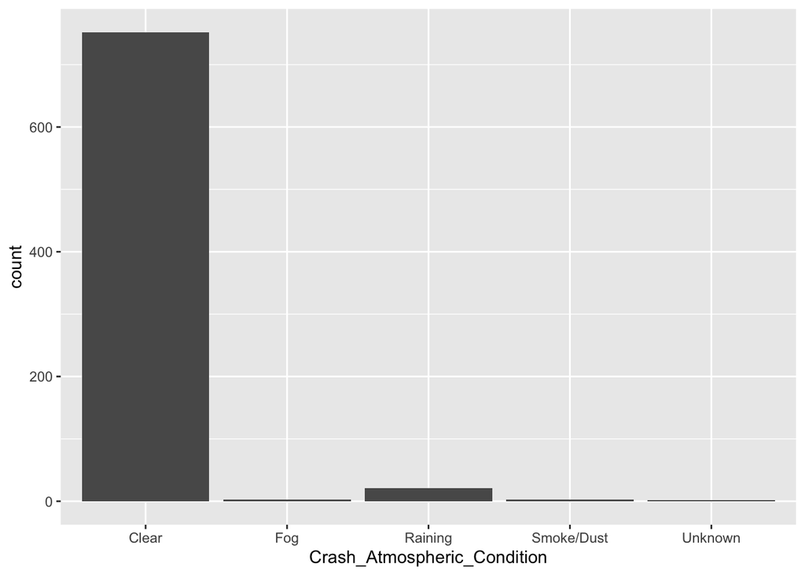

```r
ggplot(feat_counts, aes(x=Crash_Atmospheric_Condition ,y=count))+
  geom_bar(stat="identity")
```

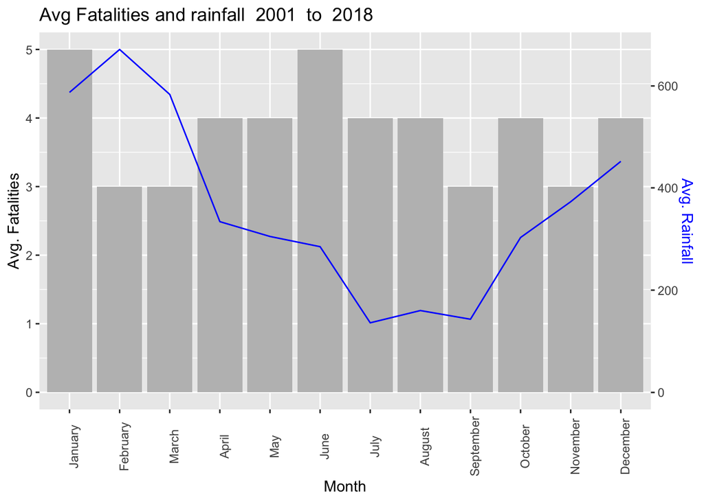

```r
feat_counts <- crashDF %>%
                 group_by(Crash_Month) %>%
                 summarise(fatalities=sum(Count_Casualty_Fatality), rainfall=sum(rainfall), .groups='drop')


numYears <- max(crashDF$Crash_Year) -min(crashDF$Crash_Year)

feat_counts$fatalities <- round( feat_counts$fatalities/numYears)

feat_counts$Crash_Month <- factor(feat_counts$Crash_Month, c("January", "February", "March","April",
                                                              "May", "June", "July",
                                                              "August", "September", "October",
                                                              "November", "December"), ordered=TRUE)

# following isn't quite right, as it sums up the rainfall for each accident - so if two accidents happen at roughly
# the same time in same area the rainfall will be doubled up - also doesn't include rainfall for days with no
#  accidents ..
# actually the concept of avg rainfall is preblematic are we considering avg rainfall for the state, avg rainfall at times of
# accidents, or something else?
feat_counts$rainfall <- round(feat_counts$rainfall/numYears)

#function(b) {b*max(feat_counts$rainfall)/max(feat_counts$fatalities)}
ggplot() +
  geom_bar(aes(x=feat_counts$Crash_Month,
               y=feat_counts$fatalities),
           stat="identity", fill="grey") +
  geom_line(aes(x=feat_counts$Crash_Month,
                y=feat_counts$rainfall*max(feat_counts$fatalities)/max(feat_counts$rainfall), group=1), colour="blue") +
  xlab("Month") +
  scale_y_continuous("Avg. Fatalities",
                     sec.axis = sec_axis(~.*max(feat_counts$rainfall)/max(feat_counts$fatalities), name="Avg. Rainfall") ) +
  ggtitle(paste("Avg Fatalities and rainfall ", min(crashDF$Crash_Year), " to ",  max(crashDF$Crash_Year))) +
   theme(axis.text.x = element_text(angle = 90), axis.title.y.right = element_text(color = "blue"))
```

# Engineer Data

Steps taken:

- Created Crash_Severity_Fac which is an ordinal factor version of Crash_Severity
- Created Crash_Severity_Num which is a numeric version of Crash_Severity_Fac
- created dummy attributes for Crash_Nature
- all columnm names renamed to replace spaces with "_".
- created non_fatal_accident column, equals 1 for a non-fatal accident, 0 for a fatal accident
- created Crash_Nature_Num as a numeric version of Crash_Nature

NOTE: from this point on analysis should use the q1CrashDF dataframe

```r
# will check to see if we previously saved away the engineered data set and load it
# rather than re-engineering the main crash data again.
# NOTE: this means that if additional engineering code is added the saved copy of q1CrashDF.Rds
# should be deleted OR the forceDfRebuild variable should be set to TRUE.
forceDfRebuild <- TRUE
q1DfFileName <-"q1CrashDF.Rds"

if( (!forceDfRebuild) & file.exists(q1DfFileName)) {
  q1CrashDF <- read_rds(q1DfFileName)
} else {


  # creat extra dummy columns for the Crash_Nature - should we drop the first one?
  #     remove_first_dummy = TRUE
  q1CrashDF <- fastDummies::dummy_cols(crashDF, select_columns= "Crash_Nature")
  names(q1CrashDF)<-str_replace_all(names(q1CrashDF), c(" " = "_" , "," = "", "-"="_" ))
  names(q1CrashDF)<-str_replace_all(names(q1CrashDF), c("___" = "_"  ))

  # replace spaces with underscore in Crash_Severity
  q1CrashDF$Crash_Severity <- str_replace_all(q1CrashDF$Crash_Severity, " ", "_")


  # may not need this as we have Count_Fatal, Count_Hospitalisation etc
  q1CrashDF$Crash_Severity_Fac <- factor(q1CrashDF$Crash_Severity, c("Property_damage_only",
        "Minor_injury",  "Medical_treatment", "Hospitalisation", "Fatal"), ordered=TRUE)

  # numeric version of Crash_Severity_Fac
  q1CrashDF$Crash_Severity_Num <- as.numeric(q1CrashDF$Crash_Severity_Fac)

  # creat a logical - 0 if fatal, 1 if non-fatal (probably smarter to reverse that)
  q1CrashDF %<>% mutate(non_fatal_accident = Count_Casualty_Fatality==0)

  q1CrashDF$Crash_Nature_Fac <- factor(q1CrashDF$Crash_Nature)

  q1CrashDF$Crash_Nature_Num <- as.numeric(q1CrashDF$Crash_Nature_Fac)

  # remove spaces from Crash_Speed_Limit
  q1CrashDF$Crash_Speed_Limit <- str_replace_all(q1CrashDF$Crash_Speed_Limit, c(" "= "", "-"="to", "/"=""))

  # create an ordinal version of speed limit
  q1CrashDF$Crash_Speed_Limit_Fac <- factor(q1CrashDF$Crash_Speed_Limit,
                                            c("0to50kmh", "60kmh", "70kmh", "80to90kmh", "100to110kmh"),
                                            ordered=TRUE)
  # create a numeric version of speed limit
  q1CrashDF$Crash_Speed_Limit_Num <- as.numeric(q1CrashDF$Crash_Speed_Limit_Fac)

   # create dummy variables for Speed limit
  q1CrashDF <- fastDummies::dummy_cols(q1CrashDF, select_columns= "Crash_Speed_Limit")


  print(names(q1CrashDF))

  write_rds(q1CrashDF, q1DfFileName)

}
```

```
##  [1] "X1"
##  [2] "crash_id"
##  [3] "Crash_Severity"
##  [4] "Crash_Year"
##  [5] "Crash_Month"
##  [6] "Crash_Day_Of_Week"
##  [7] "Crash_Hour"
##  [8] "Crash_Nature"
##  [9] "Crash_Type"
## [10] "Crash_Longitude_GDA94"
## [11] "Crash_Latitude_GDA94"
## [12] "Crash_Street"
## [13] "Loc_Suburb"
## [14] "Loc_Local_Government_Area"
## [15] "Loc_Post_Code"
```

[output cut: 58 more lines]

# Additional EDA

```r
my_data <- select(q1CrashDF,  Count_Casualty_Fatality, Count_Casualty_Hospitalised,
                  Count_Casualty_MedicallyTreated, Count_Casualty_MinorInjury,
                  Crash_Nature_Angle, Crash_Nature_Collision_miscellaneous,
                  Crash_Nature_Fall_from_vehicle, Crash_Nature_Head_on,
                  Crash_Nature_Hit_animal, Crash_Nature_Hit_object,
                  Crash_Nature_Hit_parked_vehicle, Crash_Nature_Hit_pedestrian,
                  Crash_Nature_Non_collision_miscellaneous, Crash_Nature_Overturned,
                  Crash_Nature_Rear_end, Crash_Nature_Sideswipe,
                  Crash_Nature_Struck_by_external_load
                  )

#chart.Correlation(my_data, histogram=TRUE, pch=19)
```

```r
my_data <- select(q1CrashDF,  Count_Casualty_Fatality,
                  Crash_Nature_Angle, Crash_Nature_Collision_miscellaneous,
                  Crash_Nature_Fall_from_vehicle, Crash_Nature_Head_on,
                  Crash_Nature_Hit_animal, Crash_Nature_Hit_object,
                  Crash_Nature_Hit_parked_vehicle, Crash_Nature_Hit_pedestrian,
                  Crash_Nature_Non_collision_miscellaneous, Crash_Nature_Overturned,
                  Crash_Nature_Rear_end, Crash_Nature_Sideswipe,
                  Crash_Nature_Struck_by_external_load
                  )
#chart.Correlation(my_data, histogram=TRUE, pch=19)
```

```r
corrData <- select(q1CrashDF,  Count_Casualty_Fatality, Count_Casualty_Hospitalised,
                  Count_Casualty_MedicallyTreated, Count_Casualty_MinorInjury,
                  Crash_Nature_Angle, Crash_Nature_Collision_miscellaneous,
                  Crash_Nature_Fall_from_vehicle, Crash_Nature_Head_on,
                  Crash_Nature_Hit_animal, Crash_Nature_Hit_object,
                  Crash_Nature_Hit_parked_vehicle, Crash_Nature_Hit_pedestrian,
                  Crash_Nature_Non_collision_miscellaneous, Crash_Nature_Overturned,
                  Crash_Nature_Rear_end, Crash_Nature_Sideswipe,
                  Crash_Nature_Struck_by_external_load
                  )
 result <- corrData %>% correlate()
```

```
##
## Correlation method: 'pearson'
## Missing treated using: 'pairwise.complete.obs'
```

```r
 result %>% focus(names(result)[2])  # Can't seem to be able to use Count_Casulaty_Fatality directly?
```

```
## # A tibble: 16 x 2
##    rowname                                  Count_Casualty_Fatality
##    <chr>                                                      <dbl>
##  1 Count_Casualty_Hospitalised                            -0.143
##  2 Count_Casualty_MedicallyTreated                        -0.0770
##  3 Count_Casualty_MinorInjury                             -0.0465
##  4 Crash_Nature_Angle                                     -0.0269
##  5 Crash_Nature_Collision_miscellaneous                    0.00471
##  6 Crash_Nature_Fall_from_vehicle                         -0.0390
##  7 Crash_Nature_Head_on                                    0.125
##  8 Crash_Nature_Hit_animal                                -0.00942
##  9 Crash_Nature_Hit_object                                 0.0889
## 10 Crash_Nature_Hit_parked_vehicle                        -0.00480
## 11 Crash_Nature_Hit_pedestrian                            -0.00320
## 12 Crash_Nature_Non_collision_miscellaneous                0.00400
## 13 Crash_Nature_Overturned                                -0.00845
## 14 Crash_Nature_Rear_end                                  -0.0360
## 15 Crash_Nature_Sideswipe                                 -0.0270
## 16 Crash_Nature_Struck_by_external_load                   -0.000819
```

```r
result %>% focus(names(result)[3])
```

```
## # A tibble: 16 x 2
##    rowname                                  Count_Casualty_Hospitalised
##    <chr>                                                          <dbl>
##  1 Count_Casualty_Fatality                                    -0.143
##  2 Count_Casualty_MedicallyTreated                            -0.594
##  3 Count_Casualty_MinorInjury                                 -0.320
##  4 Crash_Nature_Angle                                         -0.0162
##  5 Crash_Nature_Collision_miscellaneous                        0.0108
##  6 Crash_Nature_Fall_from_vehicle                              0.0117
##  7 Crash_Nature_Head_on                                        0.0578
##  8 Crash_Nature_Hit_animal                                     0.0312
##  9 Crash_Nature_Hit_object                                     0.0632
## 10 Crash_Nature_Hit_parked_vehicle                            -0.000883
## 11 Crash_Nature_Hit_pedestrian                                 0.0311
## 12 Crash_Nature_Non_collision_miscellaneous                   -0.00121
## 13 Crash_Nature_Overturned                                     0.0186
## 14 Crash_Nature_Rear_end                                      -0.0698
## 15 Crash_Nature_Sideswipe                                     -0.0547
## 16 Crash_Nature_Struck_by_external_load                       -0.0112
```

```r
result %>% focus(names(result)[4])
```

```
## # A tibble: 16 x 2
##    rowname                                  Count_Casualty_MedicallyTreated
##    <chr>                                                              <dbl>
##  1 Count_Casualty_Fatality                                         -0.0770
##  2 Count_Casualty_Hospitalised                                     -0.594
##  3 Count_Casualty_MinorInjury                                      -0.187
##  4 Crash_Nature_Angle                                               0.0250
##  5 Crash_Nature_Collision_miscellaneous                            -0.00697
##  6 Crash_Nature_Fall_from_vehicle                                  -0.0193
##  7 Crash_Nature_Head_on                                            -0.0176
##  8 Crash_Nature_Hit_animal                                         -0.0121
##  9 Crash_Nature_Hit_object                                         -0.0773
## 10 Crash_Nature_Hit_parked_vehicle                                 -0.0293
## 11 Crash_Nature_Hit_pedestrian                                      0.0304
## 12 Crash_Nature_Non_collision_miscellaneous                         0.00892
## 13 Crash_Nature_Overturned                                          0.00793
## 14 Crash_Nature_Rear_end                                            0.0620
## 15 Crash_Nature_Sideswipe                                           0.0289
## 16 Crash_Nature_Struck_by_external_load                             0.0162
```

```r
result %>% focus(names(result)[5])
```

```
## # A tibble: 16 x 2
##    rowname                                  Count_Casualty_MinorInjury
##    <chr>                                                         <dbl>
##  1 Count_Casualty_Fatality                                    -0.0465
##  2 Count_Casualty_Hospitalised                                -0.320
##  3 Count_Casualty_MedicallyTreated                            -0.187
##  4 Crash_Nature_Angle                                          0.0288
##  5 Crash_Nature_Collision_miscellaneous                       -0.00593
##  6 Crash_Nature_Fall_from_vehicle                             -0.0380
##  7 Crash_Nature_Head_on                                       -0.00751
##  8 Crash_Nature_Hit_animal                                    -0.0306
##  9 Crash_Nature_Hit_object                                    -0.0711
## 10 Crash_Nature_Hit_parked_vehicle                            -0.0170
## 11 Crash_Nature_Hit_pedestrian                                 0.0360
## 12 Crash_Nature_Non_collision_miscellaneous                   -0.0104
## 13 Crash_Nature_Overturned                                    -0.0104
## 14 Crash_Nature_Rear_end                                       0.0654
## 15 Crash_Nature_Sideswipe                                      0.0469
## 16 Crash_Nature_Struck_by_external_load                       -0.00882
```

Go back to the engineering level and introduce a new variable non_fatal_accidents and see if that correlation’s exist for it.

```r
corrData <- select(q1CrashDF,  non_fatal_accident,
                  Crash_Nature_Angle, Crash_Nature_Collision_miscellaneous,
                  Crash_Nature_Fall_from_vehicle, Crash_Nature_Head_on,
                  Crash_Nature_Hit_animal, Crash_Nature_Hit_object,
                  Crash_Nature_Hit_parked_vehicle, Crash_Nature_Hit_pedestrian,
                  Crash_Nature_Non_collision_miscellaneous, Crash_Nature_Overturned,
                  Crash_Nature_Rear_end, Crash_Nature_Sideswipe,
                  Crash_Nature_Struck_by_external_load
                  )
 result <- corrData %>% correlate()
```

```
##
## Correlation method: 'pearson'
## Missing treated using: 'pairwise.complete.obs'
```

```r
 result %>% focus(names(result)[2])
```

```
## # A tibble: 13 x 2
##    rowname                                  non_fatal_accident
##    <chr>                                                 <dbl>
##  1 Crash_Nature_Angle                                 0.0293
##  2 Crash_Nature_Collision_miscellaneous              -0.00514
##  3 Crash_Nature_Fall_from_vehicle                     0.0377
##  4 Crash_Nature_Head_on                              -0.119
##  5 Crash_Nature_Hit_animal                            0.00899
##  6 Crash_Nature_Hit_object                           -0.0931
##  7 Crash_Nature_Hit_parked_vehicle                    0.00449
##  8 Crash_Nature_Hit_pedestrian                        0.00285
##  9 Crash_Nature_Non_collision_miscellaneous          -0.00429
## 10 Crash_Nature_Overturned                            0.00855
## 11 Crash_Nature_Rear_end                              0.0363
## 12 Crash_Nature_Sideswipe                             0.0275
## 13 Crash_Nature_Struck_by_external_load               0.000665
```

Correlation still low. It would seem that the nature of an accident by itself has no correlation to the crash severity. However as can seen by the histograms at the start of the document a large number of accidents are the result of specific types of accidents, namely a collision at an angle and riders falling off. It is not clear if riders fall off as a result of some other accident type.

Just in case I’m doing things wrong with the above correlation let’s look at a chi-squared test

```r
chisq.test(q1CrashDF$Crash_Severity_Fac, q1CrashDF$Crash_Nature, correct=FALSE)
```

```
##
##  Pearson's Chi-squared test
##
## data:  q1CrashDF$Crash_Severity_Fac and q1CrashDF$Crash_Nature
## X-squared = 1549.7, df = 48, p-value < 2.2e-16
```

Given the low p value the chi-squared test does imply that the Nature and Severity are dependent.

```r
#  split data into 70% train 30% test.
trainSize <- floor(0.7*nrow(q1CrashDF))
set.seed(42)

trainIndexes <- sample(seq_len(nrow(q1CrashDF)), size = trainSize)
trainDF  <- q1CrashDF[trainIndexes, ]
testDF   <- q1CrashDF[-trainIndexes, ]

# model 1
# glm - gaussian
# dependent varialbe - numeric version of Crash Severity
# independent variables - all dummy variables of Crash_Nature
model1 <- glm(data=trainDF, Crash_Severity_Num ~ Crash_Nature_Angle +  Crash_Nature_Collision_miscellaneous +
             Crash_Nature_Fall_from_vehicle + Crash_Nature_Head_on +
                  Crash_Nature_Hit_animal + Crash_Nature_Hit_object +
                  Crash_Nature_Hit_parked_vehicle+ Crash_Nature_Hit_pedestrian +
                  Crash_Nature_Non_collision_miscellaneous +Crash_Nature_Overturned +
                  Crash_Nature_Rear_end + Crash_Nature_Sideswipe +
                  Crash_Nature_Struck_by_external_load, family="gaussian")

summary(model1)
```

```
##
## Call:
## glm(formula = Crash_Severity_Num ~ Crash_Nature_Angle + Crash_Nature_Collision_miscellaneous +
##     Crash_Nature_Fall_from_vehicle + Crash_Nature_Head_on + Crash_Nature_Hit_animal +
##     Crash_Nature_Hit_object + Crash_Nature_Hit_parked_vehicle +
##     Crash_Nature_Hit_pedestrian + Crash_Nature_Non_collision_miscellaneous +
##     Crash_Nature_Overturned + Crash_Nature_Rear_end + Crash_Nature_Sideswipe +
##     Crash_Nature_Struck_by_external_load, family = "gaussian",
##     data = trainDF)
##
## Deviance Residuals:
##     Min       1Q   Median       3Q      Max
## -2.9142  -0.4399   0.2859   0.5601   1.7530
##
## Coefficients: (1 not defined because of singularities)
##                                           Estimate Std. Error t value Pr(>|t|)
## (Intercept)                               3.444444   0.180061  19.129   <2e-16
## Crash_Nature_Angle                       -0.004501   0.180386  -0.025   0.9801
## Crash_Nature_Collision_miscellaneous      0.255556   0.216823   1.179   0.2386
## Crash_Nature_Fall_from_vehicle            0.065013   0.180464   0.360   0.7187
## Crash_Nature_Head_on                      0.469765   0.184355   2.548   0.0108
## Crash_Nature_Hit_animal                   0.175839   0.183844   0.956   0.3389
## Crash_Nature_Hit_object                   0.269604   0.180732   1.492   0.1358
## Crash_Nature_Hit_parked_vehicle          -0.197456   0.189572  -1.042   0.2976
## Crash_Nature_Hit_pedestrian               0.116065   0.190103   0.611   0.5415
## Crash_Nature_Non_collision_miscellaneous  0.191919   0.292363   0.656   0.5116
## Crash_Nature_Overturned                   0.184127   0.221577   0.831   0.4060
## Crash_Nature_Rear_end                    -0.151725   0.180862  -0.839   0.4015
## Crash_Nature_Sideswipe                   -0.131353   0.181335  -0.724   0.4689
## Crash_Nature_Struck_by_external_load            NA         NA      NA       NA
##
## (Intercept)                              ***
## Crash_Nature_Angle
## Crash_Nature_Collision_miscellaneous
## Crash_Nature_Fall_from_vehicle
## Crash_Nature_Head_on                     *
## Crash_Nature_Hit_animal
## Crash_Nature_Hit_object
## Crash_Nature_Hit_parked_vehicle
## Crash_Nature_Hit_pedestrian
## Crash_Nature_Non_collision_miscellaneous
## Crash_Nature_Overturned
## Crash_Nature_Rear_end
## Crash_Nature_Sideswipe
## Crash_Nature_Struck_by_external_load
## ---
## Signif. codes:  0 '***' 0.001 '**' 0.01 '*' 0.05 '.' 0.1 ' ' 1
##
## (Dispersion parameter for gaussian family taken to be 0.5835972)
##
##     Null deviance: 9629.4  on 15928  degrees of freedom
## Residual deviance: 9288.5  on 15916  degrees of freedom
## AIC: 36641
##
## Number of Fisher Scoring iterations: 2
```

```r
# prediciton throws up a "rank-deficient fit may be misleading" warning
# this is a catch all type of warning, that could inlcude rank (in this case the data has the same rank),
# sparse data or other concerns predict has about the data,  it should be thought of as
# "predicitons are brittle
#  https://stackoverflow.com/a/49862494
predictions <- predict(model1, newdata=testDF, type="response")
 print(paste("Model 1 accuracy:", sum(round(predictions)==testDF$Crash_Severity_Num)/nrow(testDF)))
```

```
## [1] "Model 1 accuracy: 0.446543643819567"
```

Model is not very poor on accuracy.

Try agin but remove crash nature with low occurrence

```r
# model 2
# glm - gaussian
# dependent varialbe - numeric version of Crash Severity
# independent variables - selected (highest incidence) dummy variables of Crash_Nature
model2<- glm(data=trainDF, Crash_Severity_Num ~ Crash_Nature_Angle +
             Crash_Nature_Fall_from_vehicle + Crash_Nature_Head_on +
                  Crash_Nature_Hit_animal + Crash_Nature_Hit_object +
                  Crash_Nature_Hit_parked_vehicle+ Crash_Nature_Hit_pedestrian +
                  Crash_Nature_Rear_end + Crash_Nature_Sideswipe, family="gaussian")

summary(model2)
```

```
##
## Call:
## glm(formula = Crash_Severity_Num ~ Crash_Nature_Angle + Crash_Nature_Fall_from_vehicle +
##     Crash_Nature_Head_on + Crash_Nature_Hit_animal + Crash_Nature_Hit_object +
##     Crash_Nature_Hit_parked_vehicle + Crash_Nature_Hit_pedestrian +
##     Crash_Nature_Rear_end + Crash_Nature_Sideswipe, family = "gaussian",
##     data = trainDF)
##
## Deviance Residuals:
##     Min       1Q   Median       3Q      Max
## -2.9142  -0.4399   0.2859   0.5601   1.7530
##
## Coefficients:
##                                  Estimate Std. Error t value Pr(>|t|)
## (Intercept)                      3.625000   0.074906  48.394  < 2e-16 ***
## Crash_Nature_Angle              -0.185056   0.075683  -2.445 0.014490 *
## Crash_Nature_Fall_from_vehicle  -0.115543   0.075869  -1.523 0.127800
## Crash_Nature_Head_on             0.289209   0.084708   3.414 0.000641 ***
## Crash_Nature_Hit_animal         -0.004717   0.083590  -0.056 0.955000
## Crash_Nature_Hit_object          0.089049   0.076503   1.164 0.244447
## Crash_Nature_Hit_parked_vehicle -0.378012   0.095531  -3.957 7.62e-05 ***
## Crash_Nature_Hit_pedestrian     -0.064490   0.096580  -0.668 0.504310
## Crash_Nature_Rear_end           -0.332281   0.076811  -4.326 1.53e-05 ***
## Crash_Nature_Sideswipe          -0.311909   0.077918  -4.003 6.28e-05 ***
## ---
## Signif. codes:  0 '***' 0.001 '**' 0.01 '*' 0.05 '.' 0.1 ' ' 1
##
## (Dispersion parameter for gaussian family taken to be 0.5835384)
##
##     Null deviance: 9629.4  on 15928  degrees of freedom
## Residual deviance: 9289.3  on 15919  degrees of freedom
## AIC: 36636
##
## Number of Fisher Scoring iterations: 2
```

```r
predictions <- predict(model2, newdata=testDF, type="response")

 print(paste("Model 2 accuracy:", sum(round(predictions)==testDF$Crash_Severity_Num)/nrow(testDF)))
```

```
## [1] "Model 2 accuracy: 0.446104276508494"
```

Very slight improvement in AIC so model is a slightly better fit but prediciton accuracy reamins unchanged.

Let’s back up a bit. Rather than using dummy variables for the Crash_Nature, lets use the numeric re-encoded column in the next model

```r
# model 3
# glm - gaussian
# dependent varialbe - numeric version of Crash Severity
# independent variables - numeric version  Crash_Nature - does this make sense as Crash_Nature is non-ordered
model3 <- glm(data=trainDF, Crash_Severity_Num ~ Crash_Nature_Num, family="gaussian")

summary(model3)
```

```
##
## Call:
## glm(formula = Crash_Severity_Num ~ Crash_Nature_Num, family = "gaussian",
##     data = trainDF)
##
## Deviance Residuals:
##     Min       1Q   Median       3Q      Max
## -2.5308  -0.5072   0.4692   0.5164   1.5989
##
## Coefficients:
##                   Estimate Std. Error t value Pr(>|t|)
## (Intercept)       3.542625   0.009760 362.964  < 2e-16 ***
## Crash_Nature_Num -0.011797   0.001594  -7.401 1.42e-13 ***
## ---
## Signif. codes:  0 '***' 0.001 '**' 0.01 '*' 0.05 '.' 0.1 ' ' 1
##
## (Dispersion parameter for gaussian family taken to be 0.6025214)
##
##     Null deviance: 9629.4  on 15928  degrees of freedom
## Residual deviance: 9596.4  on 15927  degrees of freedom
## AIC: 37138
##
## Number of Fisher Scoring iterations: 2
```

```r
predictions <- predict(model3, newdata=testDF, type="response")

 print(paste("Model 3 accuracy:", sum(round(predictions)==testDF$Crash_Severity_Num)/nrow(testDF)))
```

```
## [1] "Model 3 accuracy: 0.433216168717047"
```

Accuracy even worse.

# Ordinal Logistic Regression

Would have liked to have used the polr package but not available for this version of R, so will use the ordinal package and it’s function for cumulative link models for ordinal regresion (clm). Reference: https://marissabarlaz.github.io/portfolio/ols/

Not really expecting a different result to the attempted linear regression, just including for completeness.

Predictions are all hospitalisation!

```r
model4 <- clm(data=trainDF, Crash_Severity_Fac ~ Crash_Nature_Angle +  Crash_Nature_Collision_miscellaneous +
             Crash_Nature_Fall_from_vehicle + Crash_Nature_Head_on +
                  Crash_Nature_Hit_animal + Crash_Nature_Hit_object +
                  Crash_Nature_Hit_parked_vehicle+ Crash_Nature_Hit_pedestrian +
                  Crash_Nature_Non_collision_miscellaneous +Crash_Nature_Overturned +
                  Crash_Nature_Rear_end + Crash_Nature_Sideswipe +
                  Crash_Nature_Struck_by_external_load, link = "logit" )
summary(model4)
```

```
## formula:
## Crash_Severity_Fac ~ Crash_Nature_Angle + Crash_Nature_Collision_miscellaneous + Crash_Nature_Fall_from_vehicle + Crash_Nature_Head_on + Crash_Nature_Hit_animal + Crash_Nature_Hit_object + Crash_Nature_Hit_parked_vehicle + Crash_Nature_Hit_pedestrian + Crash_Nature_Non_collision_miscellaneous + C…
## data:    trainDF
##
##  link  threshold nobs  logLik    AIC      niter max.grad cond.H
##  logit flexible  15929 -17097.54 34227.08 7(0)  9.96e-09 1.6e+04
##
## Coefficients: (1 not defined because of singularities)
##                                          Estimate Std. Error z value Pr(>|z|)
## Crash_Nature_Angle                        0.10110    0.42521   0.238  0.81207
## Crash_Nature_Collision_miscellaneous      0.86535    0.54324   1.593  0.11117
## Crash_Nature_Fall_from_vehicle            0.26076    0.42543   0.613  0.53992
## Crash_Nature_Head_on                      1.67585    0.44196   3.792  0.00015
## Crash_Nature_Hit_animal                   0.56723    0.43518   1.303  0.19243
## Crash_Nature_Hit_object                   0.87078    0.42659   2.041  0.04122
## Crash_Nature_Hit_parked_vehicle          -0.03292    0.45358  -0.073  0.94214
## Crash_Nature_Hit_pedestrian               0.34873    0.45138   0.773  0.43978
## Crash_Nature_Non_collision_miscellaneous  0.46757    0.70821   0.660  0.50912
## Crash_Nature_Overturned                   0.44376    0.52951   0.838  0.40200
## Crash_Nature_Rear_end                    -0.26900    0.42634  -0.631  0.52806
## Crash_Nature_Sideswipe                   -0.21840    0.42756  -0.511  0.60949
## Crash_Nature_Struck_by_external_load           NA         NA      NA       NA
##
## Crash_Nature_Angle
## Crash_Nature_Collision_miscellaneous
## Crash_Nature_Fall_from_vehicle
## Crash_Nature_Head_on                     ***
## Crash_Nature_Hit_animal
## Crash_Nature_Hit_object                  *
## Crash_Nature_Hit_parked_vehicle
## Crash_Nature_Hit_pedestrian
## Crash_Nature_Non_collision_miscellaneous
## Crash_Nature_Overturned
## Crash_Nature_Rear_end
## Crash_Nature_Sideswipe
## Crash_Nature_Struck_by_external_load
## ---
## Signif. codes:  0 '***' 0.001 '**' 0.01 '*' 0.05 '.' 0.1 ' ' 1
##
## Threshold coefficients:
##                                   Estimate Std. Error z value
## Property_damage_only|Minor_injury  -4.3038     0.4307  -9.993
## Minor_injury|Medical_treatment     -1.7963     0.4247  -4.229
## Medical_treatment|Hospitalisation  -0.1360     0.4244  -0.321
## Hospitalisation|Fatal               3.7013     0.4266   8.675
```

```r
predictions <- predict(model4, newdata=testDF, type="class")
print(paste("Model 4 accuracy:", sum(as.numeric(predictions$fit)==as.numeric(testDF$Crash_Severity_Fac))/nrow(testDF)))
```

```
## [1] "Model 4 accuracy: 0.552724077328647"
```

The result looks better at .55 but not great. However, it seems all the predictions are “Hospitalisation” which suggests something is not working.

Let’s try again with least occurring accident natures removed

```r
model5<- clm(data=trainDF, Crash_Severity_Fac ~ Crash_Nature_Angle +
             Crash_Nature_Fall_from_vehicle + Crash_Nature_Head_on +
                  Crash_Nature_Hit_animal + Crash_Nature_Hit_object +
                  Crash_Nature_Hit_parked_vehicle+ Crash_Nature_Hit_pedestrian +
                  Crash_Nature_Rear_end + Crash_Nature_Sideswipe, link="logit")
summary(model5)
```

```
## formula:
## Crash_Severity_Fac ~ Crash_Nature_Angle + Crash_Nature_Fall_from_vehicle + Crash_Nature_Head_on + Crash_Nature_Hit_animal + Crash_Nature_Hit_object + Crash_Nature_Hit_parked_vehicle + Crash_Nature_Hit_pedestrian + Crash_Nature_Rear_end + Crash_Nature_Sideswipe
## data:    trainDF
##
##  link  threshold nobs  logLik    AIC      niter max.grad cond.H
##  logit flexible  15929 -17098.83 34223.66 7(0)  9.93e-09 2.7e+03
##
## Coefficients:
##                                 Estimate Std. Error z value Pr(>|z|)
## Crash_Nature_Angle              -0.40008    0.19313  -2.072 0.038312 *
## Crash_Nature_Fall_from_vehicle  -0.24043    0.19362  -1.242 0.214338
## Crash_Nature_Head_on             1.17442    0.22742   5.164 2.42e-07 ***
## Crash_Nature_Hit_animal          0.06602    0.21417   0.308 0.757889
## Crash_Nature_Hit_object          0.36952    0.19607   1.885 0.059474 .
## Crash_Nature_Hit_parked_vehicle -0.53410    0.24947  -2.141 0.032277 *
## Crash_Nature_Hit_pedestrian     -0.15247    0.24544  -0.621 0.534459
## Crash_Nature_Rear_end           -0.77016    0.19565  -3.936 8.27e-05 ***
## Crash_Nature_Sideswipe          -0.71956    0.19830  -3.629 0.000285 ***
## ---
## Signif. codes:  0 '***' 0.001 '**' 0.01 '*' 0.05 '.' 0.1 ' ' 1
##
## Threshold coefficients:
##                                   Estimate Std. Error z value
## Property_damage_only|Minor_injury  -4.8048     0.2051 -23.432
## Minor_injury|Medical_treatment     -2.2974     0.1923 -11.947
## Medical_treatment|Hospitalisation  -0.6372     0.1913  -3.331
## Hospitalisation|Fatal               3.1996     0.1957  16.349
```

```r
predictions <- predict(model5, newdata=testDF, type="class")

print(paste("Model 5 accuracy:", sum(as.numeric(predictions$fit)==as.numeric(testDF$Crash_Severity_Fac))/nrow(testDF)))
```

```
## [1] "Model 5 accuracy: 0.552724077328647"
```

# Logistic regression

Investigate the prediction value of the the nature of accidents to just fatal vs non-fatal.

```r
model6 <- glm(data=trainDF, non_fatal_accident ~ Crash_Nature_Angle +  Crash_Nature_Collision_miscellaneous +
             Crash_Nature_Fall_from_vehicle + Crash_Nature_Head_on +
                  Crash_Nature_Hit_animal + Crash_Nature_Hit_object +
                  Crash_Nature_Hit_parked_vehicle+ Crash_Nature_Hit_pedestrian +
                  Crash_Nature_Non_collision_miscellaneous +Crash_Nature_Overturned +
                  Crash_Nature_Rear_end + Crash_Nature_Sideswipe +
                  Crash_Nature_Struck_by_external_load, family = "binomial" )

summary(model6)
```

```
##
## Call:
## glm(formula = non_fatal_accident ~ Crash_Nature_Angle + Crash_Nature_Collision_miscellaneous +
##     Crash_Nature_Fall_from_vehicle + Crash_Nature_Head_on + Crash_Nature_Hit_animal +
##     Crash_Nature_Hit_object + Crash_Nature_Hit_parked_vehicle +
##     Crash_Nature_Hit_pedestrian + Crash_Nature_Non_collision_miscellaneous +
##     Crash_Nature_Overturned + Crash_Nature_Rear_end + Crash_Nature_Sideswipe +
##     Crash_Nature_Struck_by_external_load, family = "binomial",
##     data = trainDF)
##
## Deviance Residuals:
##     Min       1Q   Median       3Q      Max
## -2.8985   0.1952   0.2092   0.2188   0.6241
##
## Coefficients: (1 not defined because of singularities)
##                                            Estimate Std. Error z value Pr(>|z|)
## (Intercept)                               1.557e+01  3.430e+02   0.045    0.964
## Crash_Nature_Angle                       -1.185e+01  3.430e+02  -0.035    0.972
## Crash_Nature_Collision_miscellaneous     -1.305e+01  3.430e+02  -0.038    0.970
## Crash_Nature_Fall_from_vehicle           -1.176e+01  3.430e+02  -0.034    0.973
## Crash_Nature_Head_on                     -1.403e+01  3.430e+02  -0.041    0.967
## Crash_Nature_Hit_animal                  -1.161e+01  3.430e+02  -0.034    0.973
## Crash_Nature_Hit_object                  -1.307e+01  3.430e+02  -0.038    0.970
## Crash_Nature_Hit_parked_vehicle          -1.186e+01  3.430e+02  -0.035    0.972
## Crash_Nature_Hit_pedestrian              -1.192e+01  3.430e+02  -0.035    0.972
## Crash_Nature_Non_collision_miscellaneous  4.079e-10  5.570e+02   0.000    1.000
## Crash_Nature_Overturned                   4.076e-10  4.221e+02   0.000    1.000
## Crash_Nature_Rear_end                    -1.147e+01  3.430e+02  -0.033    0.973
## Crash_Nature_Sideswipe                   -1.138e+01  3.430e+02  -0.033    0.974
## Crash_Nature_Struck_by_external_load             NA         NA      NA       NA
##
## (Dispersion parameter for binomial family taken to be 1)
##
##     Null deviance: 4615.6  on 15928  degrees of freedom
## Residual deviance: 4309.6  on 15916  degrees of freedom
## AIC: 4335.6
##
## Number of Fisher Scoring iterations: 14
```

```r
predictions <- predict(model6, newdata=testDF, type="response")
predicted_non_fatal <- (predictions >= 0.5)

print(paste("Model 5 accuracy:", sum(predicted_non_fatal==testDF$non_fatal_accident)/nrow(testDF)))
```

```
## [1] "Model 5 accuracy: 0.965436438195665"
```

This has a very high accuracy but really doesn’t tell us very much. The model seems to just assume that everything is non-fatal as the number of fatal accidents is actually very low; percentage of non-fatal accidents in the test set is 0.9654364 which is the same as the model accuracy.

# Include Speed Zone data

Try some models with crash seveirty and crash speed limit.

Must be doing something wrong prediciton is alway sHospitalisation.

```r
model7<- clm(data=trainDF, Crash_Severity_Fac ~ Crash_Nature_Angle + Crash_Nature_Collision_miscellaneous +
    Crash_Nature_Fall_from_vehicle + Crash_Nature_Head_on + Crash_Nature_Hit_animal +
    Crash_Nature_Hit_object + Crash_Nature_Hit_parked_vehicle +
    Crash_Nature_Hit_pedestrian +
    Crash_Nature_Overturned +
    Crash_Speed_Limit_0to50kmh + Crash_Speed_Limit_100to110kmh +
    Crash_Speed_Limit_60kmh+  Crash_Speed_Limit_70kmh,
    link="logit")
summary(model7)
```

```
## formula:
## Crash_Severity_Fac ~ Crash_Nature_Angle + Crash_Nature_Collision_miscellaneous + Crash_Nature_Fall_from_vehicle + Crash_Nature_Head_on + Crash_Nature_Hit_animal + Crash_Nature_Hit_object + Crash_Nature_Hit_parked_vehicle + Crash_Nature_Hit_pedestrian + Crash_Nature_Overturned + Crash_Speed_Limit_…
## data:    trainDF
##
##  link  threshold nobs  logLik    AIC      niter max.grad cond.H
##  logit flexible  15929 -16956.60 33947.21 7(0)  1.34e-08 7.4e+02
##
## Coefficients:
##                                      Estimate Std. Error z value Pr(>|z|)
## Crash_Nature_Angle                    0.45070    0.04286  10.515  < 2e-16 ***
## Crash_Nature_Collision_miscellaneous  0.97102    0.34183   2.841  0.00450 **
## Crash_Nature_Fall_from_vehicle        0.46296    0.04493  10.303  < 2e-16 ***
## Crash_Nature_Head_on                  1.87220    0.12662  14.786  < 2e-16 ***
## Crash_Nature_Hit_animal               0.55348    0.10405   5.319 1.04e-07 ***
## Crash_Nature_Hit_object               1.05978    0.05488  19.312  < 2e-16 ***
## Crash_Nature_Hit_parked_vehicle       0.30677    0.16471   1.863  0.06253 .
## Crash_Nature_Hit_pedestrian           0.72897    0.15807   4.612 4.00e-06 ***
## Crash_Nature_Overturned               0.58165    0.31953   1.820  0.06871 .
## Crash_Speed_Limit_0to50kmh           -0.56537    0.06340  -8.918  < 2e-16 ***
## Crash_Speed_Limit_100to110kmh         0.23156    0.06824   3.393  0.00069 ***
## Crash_Speed_Limit_60kmh              -0.49454    0.05619  -8.802  < 2e-16 ***
## Crash_Speed_Limit_70kmh              -0.21032    0.08479  -2.481  0.01312 *
## ---
## Signif. codes:  0 '***' 0.001 '**' 0.01 '*' 0.05 '.' 0.1 ' ' 1
##
## Threshold coefficients:
##                                   Estimate Std. Error z value
## Property_damage_only|Minor_injury -4.42334    0.09412 -46.996
## Minor_injury|Medical_treatment    -1.91086    0.06193 -30.856
## Medical_treatment|Hospitalisation -0.23404    0.05950  -3.934
## Hospitalisation|Fatal              3.65317    0.07325  49.874
```

```r
predictions <- predict(model7, newdata=testDF, type="class")

print(paste("Model 7 accuracy:", sum(as.numeric(predictions$fit)==as.numeric(testDF$Crash_Severity_Fac))/nrow(testDF)))
```

```
## [1] "Model 7 accuracy: 0.552724077328647"
```